# Quiz 1: Part 2

## Part 2: Coding in action

### Instructions

Please answer these questions in R using whatever syntax makes sense to you. Feel free to use the R help pages and/or notes from class.

**If you use Google or ChatGPT etc. to help you get to an answer, please note so on your answer**

Step 1. ARE YOU IN A BRANCH?????  
Step 2. Save this file as lastname_quiz.qmd in the same quiz folder.  
Step 3. Once you are done, click “render” above. This will create the .html file that I will evaluate.  
Step 4. Stage and commit your changes, push to your github.  
Step 5. Submit a pull request. If github warns you of conflicts please try and fix them before submitting your pull request (did you rename the file??? ).  
(Step 6. In case of utter disaster, email Sabrina your .html file.)

```r
# load packages and data
library(ggplot2)
library(dslabs)
library(dplyr)
#library(quarto)
```

#### Load your data:

Load the *swallows.csv* into R, call it swallows. This data frame lists results of an experiment on tree swallows. Each row is a nest. Nests were put into one of two **treatments**: simulated predation (predator), or control (control). Along with treatment you have the following columns:  
**nest_fate** = whether the nest fledged any young or whether they all died  
**brood** = number of nestlings  
**n_fledged** = number of nestlings that fledged.

You also have a separate data frame called *brightness.csv* where each row lists the plumage brightness (a sexual signal) for the female at each nest. Load this one up too.

```r
# Type your answer in this box using R code

swallows <- read.csv("swallows.csv")
brightness <- read.csv("brightness.csv")

# Google? n
```

#### Wrangle your data

```r
#Answer

swallows <- inner_join(swallows, brightness, by="nestbox")

#I would check to make sure that this worked as I intended by making sure I retained the same number of rows and only added the brightness column to my main swallows dataframe.


#Google? n
```

Inspect your combined data frame. Do some sort of quick sanity check on each column to catch any obvious entry errors. Correct as necessary

```r
# Answer

unique(swallows$treatment) # make sure there are only control and predation columns
```

```
[1] "Control"   "Predation"
```

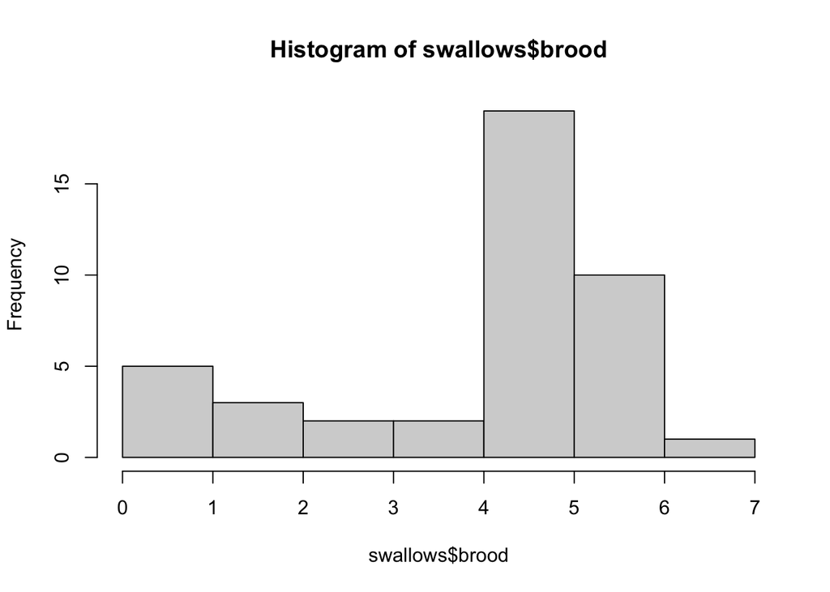

```r
hist(swallows$brood) # data is a little left-skewed
```

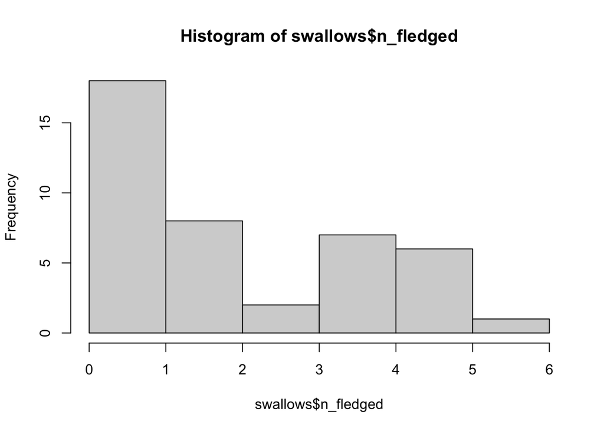

```r
hist(swallows$n_fledged) # a lot of birds did not fledge
```

```r
mean(swallows$brightness) # one NA
```

```
[1] NA
```

```r
mean(swallows$brightness, na.rm=T) # 51.197
```

```
[1] 51.19756
```

```r
# Google y/n n
```

Create a new column called prop_fledged that contains the proportion of nestlings that fledged from each nest.

```r
#Answer

swallows <- mutate(swallows, prop_fledged=n_fledged/brood)

# Google? y/n n
```

#### Explore the data

What was the mean proportion of nestlings fledged in each treatment?

```r
# Answer

swallows %>%
  filter(treatment == "Predation") %>%
  pull(prop_fledged) %>%
  mean(na.rm=TRUE) #.335
```

```
[1] 0.3349206
```

```r
swallows %>%
  filter(treatment == "Control") %>%
  pull(prop_fledged) %>%
  mean(na.rm=TRUE) # .7055
```

```
[1] 0.7055556
```

```r
# Google? y/n y needed help with pull()
```

Create a plot showing fledging success differences between treatments

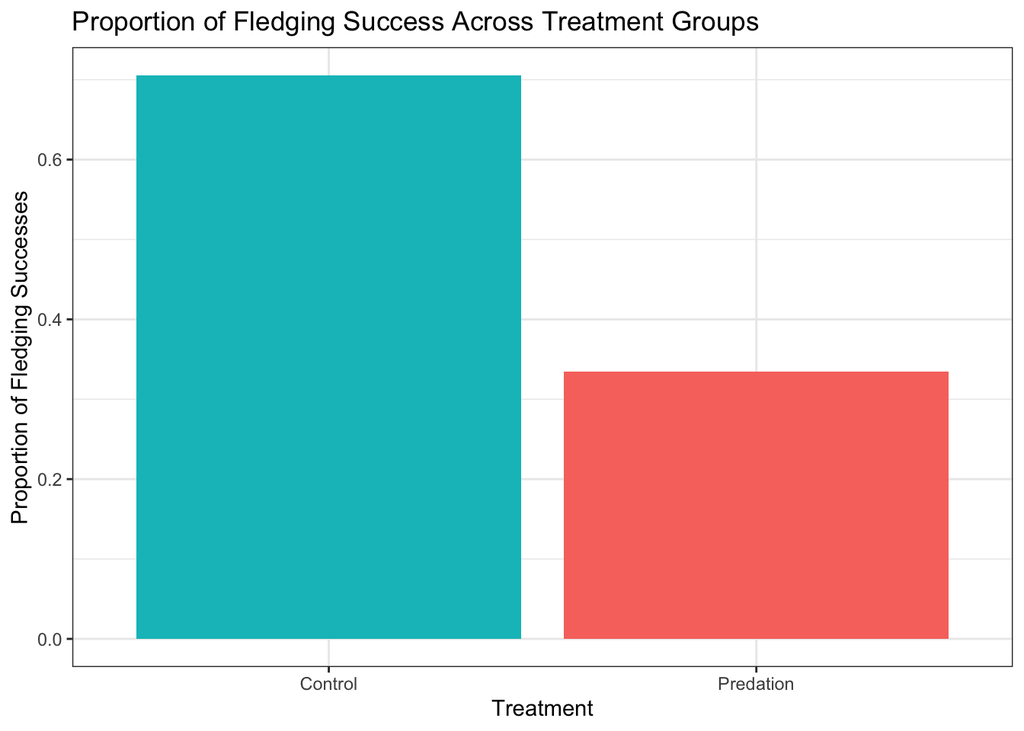

```r
# Answer

agg_data <- aggregate(prop_fledged ~ treatment,
                      data = swallows,
                      FUN = mean)

# Plot
ggplot(agg_data, aes(treatment, prop_fledged, fill=c('red', 'blue'))) +
  geom_col(show.legend=FALSE) +
  xlab('Treatment') +
  ylab('Proportion of Fledging Successes') +
  ggtitle('Proportion of Fledging Success Across Treatment Groups') +
  theme(legend.position = "none") +
  theme_bw()
```

```r
#looked at this to make sure mean props were right
#mean.control <- swallows %>%
 # filter(treatment=="Control")
#mean(mean.control$prop_fledged, na.rm=T)

#mean.predation <- swallows %>%
 # filter(treatment=="Predation")
  #mean(mean.predation$prop_fledged, na.rm=T)

# Google? y/n y could not remember aggregate() syntax
```

Is there any evidence that female brightness influenced fledging success? Create a plot to visually investigate this question.

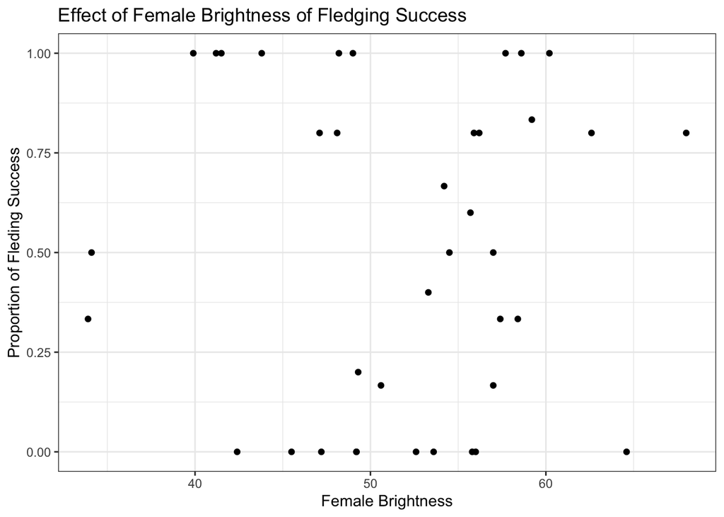

```r
# Answer

ggplot(swallows, aes(brightness, prop_fledged)) + geom_point() +
  xlab('Female Brightness') +
  ylab('Proportion of Fleding Success') +
  ggtitle('Effect of Female Brightness of Fledging Success') +
  theme_bw()
```

```r
# Google? y/n n

# there does not appear to be any evidence that female brightness induces fledging success. the data does not show any correlation between brightness and fledging success.
```